# Capstone 1 - K Means Clustering Analysis on IPL Data

Sushil Mendon

2023-03-28

# Import Packages

```r
library(dplyr)
library(factoextra)
```

```r
library(ggplot2)
library(ggthemes)
library(knitr)
library(readxl)
```

# Importing the Data

```r
ipl_batsmen_data <- read_excel("C:/Users/user/Desktop/Sushil/DABS/Capstone 1/IPL_Spreadsheet.xlsx",
                               sheet = 2)
```

# IPL Dataset

## Description

The `ipl_batsmen_data` provides data on 70 players from the 2019 edition of the IPL. The dataset provides observations on 7 variables and also contains the cost of each of the players.

```r
ipl_batsmen_data
```

```
## # A tibble: 70 × 12
##     ...1 ...2  Player Team   Runs   Avg    SR Hundr…¹ Fifties Fours Sixes Salary
##    <dbl> <lgl> <chr>  <chr> <dbl> <dbl> <dbl>   <dbl>   <dbl> <dbl> <dbl>  <dbl>
##  1     1 NA    AB de… Roya…   442  44.2 154         0       5    31    26  1.72
##  2     2 NA    Ajink… Raja…   393  32.8 138.        1       1    45     9  0.625
##  3     3 NA    Akshd… Roya…    61  12.2 107.        0       0     5     2  0.514
##  4     4 NA    Ambat… Chen…   282  23.5  93.1       0       1    20     7  0.344
##  5     5 NA    Andre… Kolk…   510  56.7 205.        0       4    31    52  1.33
##  6     6 NA    Axar … Roya…   110  18.3 125         0       0    10     3  0.714
##  7     7 NA    Ben S… Raja…   123  20.5 124.        0       0     8     4  1.95
##  8     8 NA    Bhuvn… Sunr…    12   4    63.2       0       0     1     0  1.33
##  9     9 NA    Chris… King…   490  40.8 154.        0       4    45    34  0.312
## 10    10 NA    Chris… Kolk…   405  31.2 140.        0       4    41    22  1.5
## # … with 60 more rows, and abbreviated variable name ¹Hundreds
```

## Objective & Approach

The objective is to analyse the data provided and arrive at an objective classification of players based on their performances. The analyst seeks to identify “good value” acquisitions across the categories. The K-Means Clustering Analysis will be employed to classify players into clusters. The analyst acknowledges that the data contains players who may have been acquired for skills other that batmanship. The current analysis is restricted only their performances in batting.

# Cleaning and Preparing the data for analysis

### Renaming the dataset

```r
df <- ipl_batsmen_data
df
```

```
## # A tibble: 70 × 12
##     ...1 ...2  Player Team   Runs   Avg    SR Hundr…¹ Fifties Fours Sixes Salary
##    <dbl> <lgl> <chr>  <chr> <dbl> <dbl> <dbl>   <dbl>   <dbl> <dbl> <dbl>  <dbl>
##  1     1 NA    AB de… Roya…   442  44.2 154         0       5    31    26  1.72
##  2     2 NA    Ajink… Raja…   393  32.8 138.        1       1    45     9  0.625
##  3     3 NA    Akshd… Roya…    61  12.2 107.        0       0     5     2  0.514
##  4     4 NA    Ambat… Chen…   282  23.5  93.1       0       1    20     7  0.344
##  5     5 NA    Andre… Kolk…   510  56.7 205.        0       4    31    52  1.33
##  6     6 NA    Axar … Roya…   110  18.3 125         0       0    10     3  0.714
##  7     7 NA    Ben S… Raja…   123  20.5 124.        0       0     8     4  1.95
##  8     8 NA    Bhuvn… Sunr…    12   4    63.2       0       0     1     0  1.33
##  9     9 NA    Chris… King…   490  40.8 154.        0       4    45    34  0.312
## 10    10 NA    Chris… Kolk…   405  31.2 140.        0       4    41    22  1.5
## # … with 60 more rows, and abbreviated variable name ¹Hundreds
```

### Omitting columns 1 & 2

Omitting columns 1 & 2 containg index and blank values respectively

```r
df <- df[ , -c(1,2)]
df
```

```
## # A tibble: 70 × 10
##    Player            Team    Runs   Avg    SR Hundr…¹ Fifties Fours Sixes Salary
##    <chr>             <chr>  <dbl> <dbl> <dbl>   <dbl>   <dbl> <dbl> <dbl>  <dbl>
##  1 AB de Villiers    Royal…   442  44.2 154         0       5    31    26  1.72
##  2 Ajinkya Rahane    Rajas…   393  32.8 138.        1       1    45     9  0.625
##  3 Akshdeep Nath     Royal…    61  12.2 107.        0       0     5     2  0.514
##  4 Ambati Rayudu     Chenn…   282  23.5  93.1       0       1    20     7  0.344
##  5 Andre Russell     Kolka…   510  56.7 205.        0       4    31    52  1.33
##  6 Axar Patel        Royal…   110  18.3 125         0       0    10     3  0.714
##  7 Ben Stokes        Rajas…   123  20.5 124.        0       0     8     4  1.95
##  8 Bhuvneshwar Kumar Sunri…    12   4    63.2       0       0     1     0  1.33
##  9 Chris Gayle       Kings…   490  40.8 154.        0       4    45    34  0.312
## 10 Chris Lynn        Kolka…   405  31.2 140.        0       4    41    22  1.5
## # … with 60 more rows, and abbreviated variable name ¹Hundreds
```

### Creating a ROI measure

Creating a ROI measure as a ratio of runs per $1000 spent on the player

```r
df$runs_per_k <- df$Runs / (df$Salary * 1000)
df$runs_per_k <- round(df$runs_per_k, digits = 2)
df
```

```
## # A tibble: 70 × 11
##    Player     Team   Runs   Avg    SR Hundr…¹ Fifties Fours Sixes Salary runs_…²
##    <chr>      <chr> <dbl> <dbl> <dbl>   <dbl>   <dbl> <dbl> <dbl>  <dbl>   <dbl>
##  1 AB de Vil… Roya…   442  44.2 154         0       5    31    26  1.72     0.26
##  2 Ajinkya R… Raja…   393  32.8 138.        1       1    45     9  0.625    0.63
##  3 Akshdeep … Roya…    61  12.2 107.        0       0     5     2  0.514    0.12
##  4 Ambati Ra… Chen…   282  23.5  93.1       0       1    20     7  0.344    0.82
##  5 Andre Rus… Kolk…   510  56.7 205.        0       4    31    52  1.33     0.38
##  6 Axar Patel Roya…   110  18.3 125         0       0    10     3  0.714    0.15
##  7 Ben Stokes Raja…   123  20.5 124.        0       0     8     4  1.95     0.06
##  8 Bhuvneshw… Sunr…    12   4    63.2       0       0     1     0  1.33     0.01
##  9 Chris Gay… King…   490  40.8 154.        0       4    45    34  0.312    1.57
## 10 Chris Lynn Kolk…   405  31.2 140.        0       4    41    22  1.5      0.27
## # … with 60 more rows, and abbreviated variable names ¹Hundreds, ²runs_per_k
```

### Rounding off the Salary column

```r
df$Salary <- round(df$Salary, digits = 2)
df
```

```
## # A tibble: 70 × 11
##    Player     Team   Runs   Avg    SR Hundr…¹ Fifties Fours Sixes Salary runs_…²
##    <chr>      <chr> <dbl> <dbl> <dbl>   <dbl>   <dbl> <dbl> <dbl>  <dbl>   <dbl>
##  1 AB de Vil… Roya…   442  44.2 154         0       5    31    26   1.72    0.26
##  2 Ajinkya R… Raja…   393  32.8 138.        1       1    45     9   0.62    0.63
##  3 Akshdeep … Roya…    61  12.2 107.        0       0     5     2   0.51    0.12
##  4 Ambati Ra… Chen…   282  23.5  93.1       0       1    20     7   0.34    0.82
##  5 Andre Rus… Kolk…   510  56.7 205.        0       4    31    52   1.33    0.38
##  6 Axar Patel Roya…   110  18.3 125         0       0    10     3   0.71    0.15
##  7 Ben Stokes Raja…   123  20.5 124.        0       0     8     4   1.95    0.06
##  8 Bhuvneshw… Sunr…    12   4    63.2       0       0     1     0   1.33    0.01
##  9 Chris Gay… King…   490  40.8 154.        0       4    45    34   0.31    1.57
## 10 Chris Lynn Kolk…   405  31.2 140.        0       4    41    22   1.5     0.27
## # … with 60 more rows, and abbreviated variable names ¹Hundreds, ²runs_per_k
```

# K-Means Clustering Analysis

### Normalising the data points to be used in the analysis

```r
n_df <- scale(df[ , 3:9])
```

### Determining the ideal number of clusters using the Elbow, Silhouette, Gap Statistic Methods

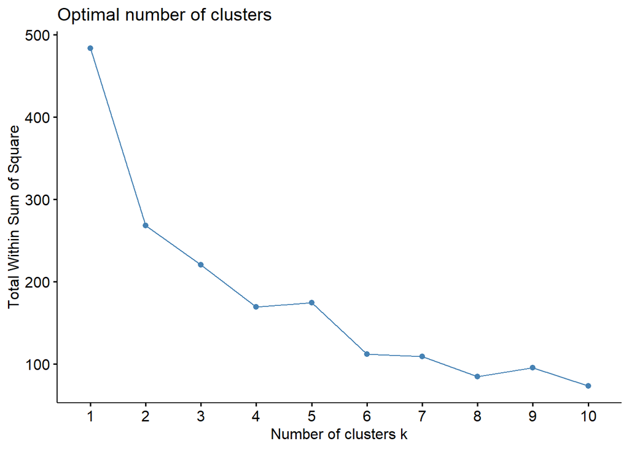

```r
elbow_plot <- fviz_nbclust(n_df, kmeans, method = "wss")
elbow_plot
```

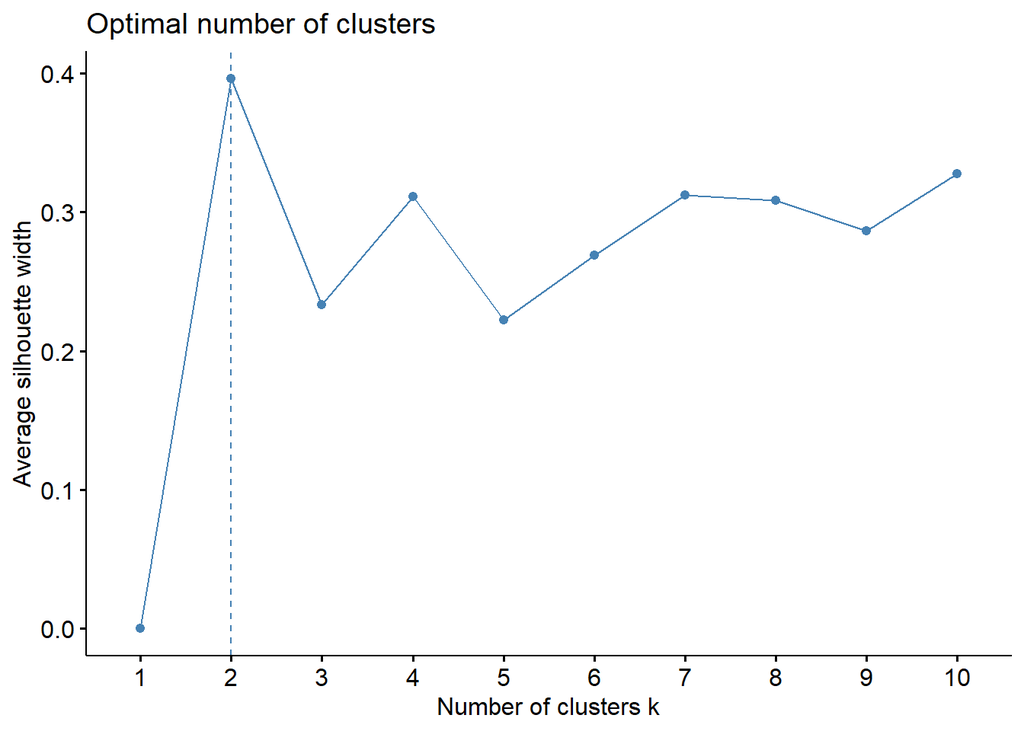

```r
silhouette_plot <- fviz_nbclust(n_df, kmeans, method = "silhouette")
silhouette_plot
```

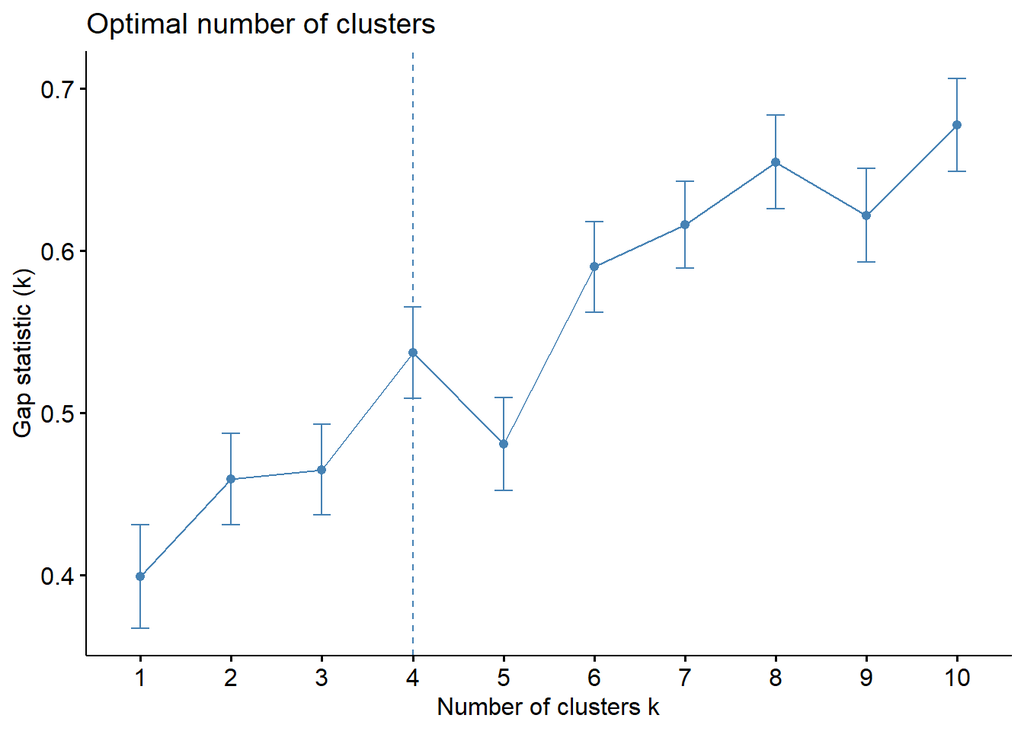

```r
gap_stat <- fviz_nbclust(n_df, kmeans, method = "gap_stat")
gap_stat
```

Both the Elbow and Gap Statistic methods indicate 4 as the ideal number of clusters for the current analysis.

### K-Means Analysis

```r
set.seed(2703)

kmeans_4cl <- kmeans(n_df, 4, nstart = 25)
kmeans_4cl
```

```
## K-means clustering with 4 clusters of sizes 6, 6, 21, 37
##
## Cluster means:
##         Runs        Avg          SR   Hundreds    Fifties      Fours      Sixes
## 1  1.2370084  1.5176928  1.33963042 -0.3039913  1.0654740  0.5896937  2.2273208
## 2  1.4157758  1.2012910  0.43562184  3.2425739  0.9693617  1.3713348  0.6253612
## 3  0.6760145  0.2087239  0.06149259 -0.3039913  0.6810246  0.8186736  0.3293470
## 4 -0.8138651 -0.5593812 -0.32277994 -0.3039913 -0.7165009 -0.7826572 -0.6495237
##
## Clustering vector:
##  [1] 1 2 4 4 1 4 4 4 1 3 4 4 2 4 4 3 4 3 1 4 4 2 3 4 4 4 3 2 4 4 3 4 3 3 4 1 4 3
## [39] 3 4 3 3 4 4 4 4 1 4 3 3 4 2 4 3 4 3 4 4 3 3 3 4 4 3 3 4 4 2 4 4
##
## Within cluster sum of squares by cluster:
## [1] 22.52157 28.54958 37.42507 78.08677
##  (between_SS / total_SS =  65.5 %)
##
## Available components:
##
## [1] "cluster"      "centers"      "totss"        "withinss"     "tot.withinss"
## [6] "betweenss"    "size"         "iter"         "ifault"
```

### Adding clusters to the data frame

```r
df$cluster <- kmeans_4cl$cluster
df
```

```
## # A tibble: 70 × 12
##    Player     Team   Runs   Avg    SR Hundr…¹ Fifties Fours Sixes Salary runs_…²
##    <chr>      <chr> <dbl> <dbl> <dbl>   <dbl>   <dbl> <dbl> <dbl>  <dbl>   <dbl>
##  1 AB de Vil… Roya…   442  44.2 154         0       5    31    26   1.72    0.26
##  2 Ajinkya R… Raja…   393  32.8 138.        1       1    45     9   0.62    0.63
##  3 Akshdeep … Roya…    61  12.2 107.        0       0     5     2   0.51    0.12
##  4 Ambati Ra… Chen…   282  23.5  93.1       0       1    20     7   0.34    0.82
##  5 Andre Rus… Kolk…   510  56.7 205.        0       4    31    52   1.33    0.38
##  6 Axar Patel Roya…   110  18.3 125         0       0    10     3   0.71    0.15
##  7 Ben Stokes Raja…   123  20.5 124.        0       0     8     4   1.95    0.06
##  8 Bhuvneshw… Sunr…    12   4    63.2       0       0     1     0   1.33    0.01
##  9 Chris Gay… King…   490  40.8 154.        0       4    45    34   0.31    1.57
## 10 Chris Lynn Kolk…   405  31.2 140.        0       4    41    22   1.5     0.27
## # … with 60 more rows, 1 more variable: cluster <int>, and abbreviated variable
## #   names ¹Hundreds, ²runs_per_k
```

# Analysis of Resultant Clusters

## Cluster Classification

The ranking of clusters was found to be 2, 1, 3, 4. The same shall be now classified as : 2 = “Excellent”, 1 = “Good”, 3 = “Average Acquisition”, 4 = “Underperforming”

```r
df$classification <- ifelse(df$cluster == 2, "Excellent",
                            ifelse(df$cluster == 1, "Good",
                                   if_else(df$cluster == 3, "Average", "Underperforming")))

df$classification <- factor(df$classification, levels = c("Excellent", "Good", "Average",
                            "Underperforming"), ordered = T)

levels(df$classification)
```

```
## [1] "Excellent"       "Good"            "Average"         "Underperforming"
```

### Sub-setting the data for analysis and visualization

```r
sub_df <- df[ , -c(8:9)]
sub_df
```

```
## # A tibble: 70 × 11
##    Player Team   Runs   Avg    SR Hundr…¹ Fifties Salary runs_…² cluster class…³
##    <chr>  <chr> <dbl> <dbl> <dbl>   <dbl>   <dbl>  <dbl>   <dbl>   <int> <ord>
##  1 AB de… Roya…   442  44.2 154         0       5   1.72    0.26       1 Good
##  2 Ajink… Raja…   393  32.8 138.        1       1   0.62    0.63       2 Excell…
##  3 Akshd… Roya…    61  12.2 107.        0       0   0.51    0.12       4 Underp…
##  4 Ambat… Chen…   282  23.5  93.1       0       1   0.34    0.82       4 Underp…
##  5 Andre… Kolk…   510  56.7 205.        0       4   1.33    0.38       1 Good
##  6 Axar … Roya…   110  18.3 125         0       0   0.71    0.15       4 Underp…
##  7 Ben S… Raja…   123  20.5 124.        0       0   1.95    0.06       4 Underp…
##  8 Bhuvn… Sunr…    12   4    63.2       0       0   1.33    0.01       4 Underp…
##  9 Chris… King…   490  40.8 154.        0       4   0.31    1.57       1 Good
## 10 Chris… Kolk…   405  31.2 140.        0       4   1.5     0.27       3 Average
## # … with 60 more rows, and abbreviated variable names ¹Hundreds, ²runs_per_k,
## #   ³classification
```

```r
mean(sub_df$Salary)
```

```
## [1] 0.912
```

## Cluster-wise analysis to understand the value and performance of the players

### Cluster 2 (Classification: Excellent)

```r
cluster2 <- sub_df %>% filter(cluster == 2)

cluster2 %>% arrange(desc(Runs))
```

```
## # A tibble: 6 × 11
##   Player  Team   Runs   Avg    SR Hundr…¹ Fifties Salary runs_…² cluster class…³
##   <chr>   <chr> <dbl> <dbl> <dbl>   <dbl>   <dbl>  <dbl>   <dbl>   <int> <ord>
## 1 David … Sunr…   692  69.2  144.       1       8   1.95    0.35       2 Excell…
## 2 KL Rah… King…   593  53.9  135.       1       6   1.72    0.35       2 Excell…
## 3 Virat … Roya…   464  33.1  141.       1       2   2.66    0.17       2 Excell…
## 4 Jonny … Sunr…   445  55.6  157.       1       2   0.31    1.42       2 Excell…
## 5 Ajinky… Raja…   393  32.8  138.       1       1   0.62    0.63       2 Excell…
## 6 Sanju … Raja…   342  34.2  149.       1       0   1.25    0.27       2 Excell…
## # … with abbreviated variable names ¹Hundreds, ²runs_per_k, ³classification
```

```r
cluster2 %>% arrange(desc(runs_per_k))
```

```
## # A tibble: 6 × 11
##   Player  Team   Runs   Avg    SR Hundr…¹ Fifties Salary runs_…² cluster class…³
##   <chr>   <chr> <dbl> <dbl> <dbl>   <dbl>   <dbl>  <dbl>   <dbl>   <int> <ord>
## 1 Jonny … Sunr…   445  55.6  157.       1       2   0.31    1.42       2 Excell…
## 2 Ajinky… Raja…   393  32.8  138.       1       1   0.62    0.63       2 Excell…
## 3 David … Sunr…   692  69.2  144.       1       8   1.95    0.35       2 Excell…
## 4 KL Rah… King…   593  53.9  135.       1       6   1.72    0.35       2 Excell…
## 5 Sanju … Raja…   342  34.2  149.       1       0   1.25    0.27       2 Excell…
## 6 Virat … Roya…   464  33.1  141.       1       2   2.66    0.17       2 Excell…
## # … with abbreviated variable names ¹Hundreds, ²runs_per_k, ³classification
```

Cluster 2 looks to consist of all the players to have scored a Hundred in this edition. Top performer David Warner also comes at high cost of 1.95M Dollars. A good value acquisition in this group is Jonny Bairstow with a cost of 0.31M Dollars.

```r
cluster2 %>% summarise(mean(Salary))
```

```
## # A tibble: 1 × 1
##   `mean(Salary)`
##            <dbl>
## 1           1.42
```

[output not shown]

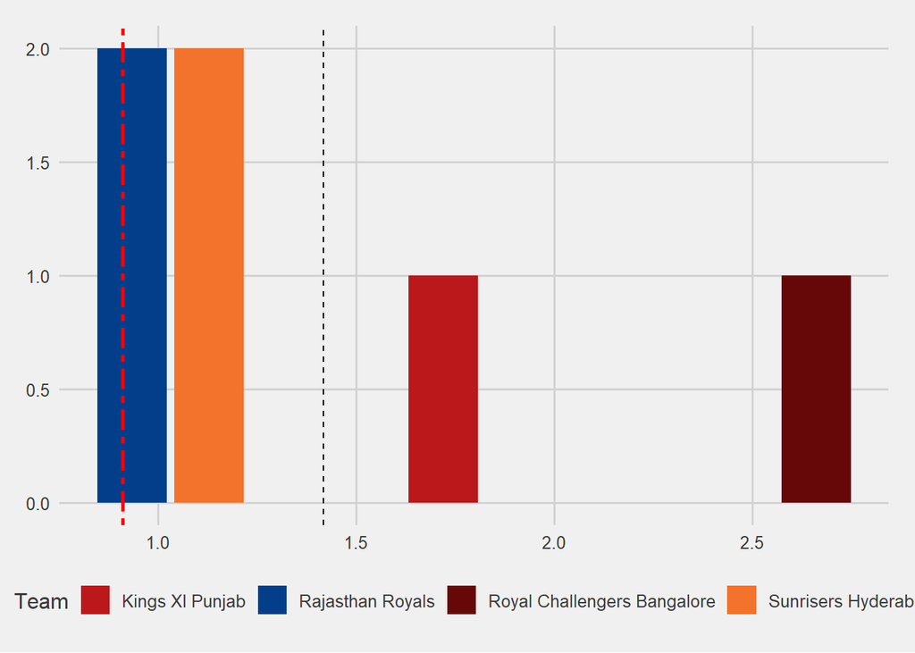

The distribution of salary in Cluster 2 and comparison to overall average.

```r
cluster2 %>% group_by(Team) %>% mutate(Avg_Salary = mean(Salary)) %>%
  ggplot(aes(Avg_Salary, fill = Team)) +
  geom_bar() +
  geom_vline(xintercept = mean(cluster2$Salary), linetype = 2) +
  geom_vline(xintercept = mean(sub_df$Salary), linetype = 6 , size = 1, color = "red")+
  scale_fill_manual(values = c("Kings XI Punjab" = "#ba181b",
                                "Rajasthan Royals" = "#023e8a",
                                "Royal Challengers Bangalore" = "#660708",
                                "Sunrisers Hyderabad" = "#f3722c")) +
  theme_fivethirtyeight()
```

The average money spent in this cluster is 1.41M Dollars, which is higher than the overall average of 0.9M Dollars. Both RR and SRH feature 2 players in this cluster and have an average spend below the cluster average.

### Cluster 1 (Classification: Good)

```r
cluster1 <- sub_df %>% filter(cluster == 1)

cluster1 %>% arrange(desc(Runs))
```

```
## # A tibble: 6 × 11
##   Player  Team   Runs   Avg    SR Hundr…¹ Fifties Salary runs_…² cluster class…³
##   <chr>   <chr> <dbl> <dbl> <dbl>   <dbl>   <dbl>  <dbl>   <dbl>   <int> <ord>
## 1 Andre … Kolk…   510  56.7  205.       0       4   1.33    0.38       1 Good
## 2 Chris … King…   490  40.8  154.       0       4   0.31    1.57       1 Good
## 3 Rishab… Delh…   488  37.5  163.       0       3   2.34    0.21       1 Good
## 4 AB de … Roya…   442  44.2  154        0       5   1.72    0.26       1 Good
## 5 MS Dho… Chen…   416  83.2  135.       0       3   2.34    0.18       1 Good
## 6 Hardik… Mumb…   402  44.7  191.       0       1   1.72    0.23       1 Good
## # … with abbreviated variable names ¹Hundreds, ²runs_per_k, ³classification
```

```r
cluster1 %>% arrange(desc(runs_per_k))
```

```
## # A tibble: 6 × 11
##   Player  Team   Runs   Avg    SR Hundr…¹ Fifties Salary runs_…² cluster class…³
##   <chr>   <chr> <dbl> <dbl> <dbl>   <dbl>   <dbl>  <dbl>   <dbl>   <int> <ord>
## 1 Chris … King…   490  40.8  154.       0       4   0.31    1.57       1 Good
## 2 Andre … Kolk…   510  56.7  205.       0       4   1.33    0.38       1 Good
## 3 AB de … Roya…   442  44.2  154        0       5   1.72    0.26       1 Good
## 4 Hardik… Mumb…   402  44.7  191.       0       1   1.72    0.23       1 Good
## 5 Rishab… Delh…   488  37.5  163.       0       3   2.34    0.21       1 Good
## 6 MS Dho… Chen…   416  83.2  135.       0       3   2.34    0.18       1 Good
## # … with abbreviated variable names ¹Hundreds, ²runs_per_k, ³classification
```

Cluster 1 consists consistent batsmen that haven’t scored a Hundred but are comparable to players in Cluster 2 in most other parameters. The best value pick up in the cluster is Chris Gayle with a cost of $0.31M.

```r
cluster1 %>% summarise(mean(Salary))
```

```
## # A tibble: 1 × 1
##   `mean(Salary)`
##            <dbl>
## 1           1.63
```

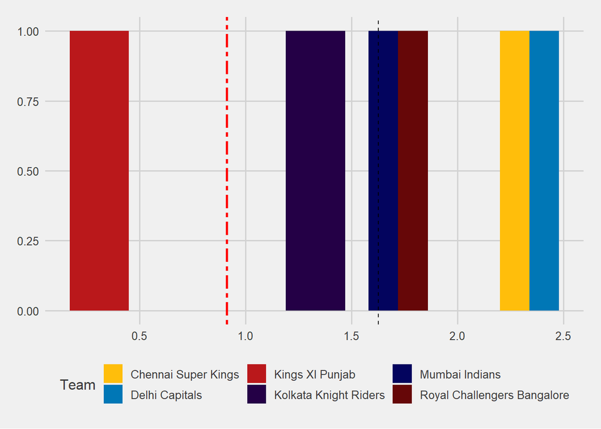

The distribution of salary in Cluster 1 and comparison to overall average.

```r
cluster1 %>% group_by(Team) %>% mutate(Avg_Salary = mean(Salary)) %>%
  ggplot(aes(Avg_Salary, fill = Team)) +
  geom_bar(position = "dodge") +
  geom_vline(xintercept = mean(cluster1$Salary), linetype = 2) +
  geom_vline(xintercept = mean(sub_df$Salary), linetype = 6 , size = 1, color = "red")+
  scale_fill_manual(values = c("Kings XI Punjab" = "#ba181b",
                               "Royal Challengers Bangalore" = "#660708",
                               "Kolkata Knight Riders" = "#240046",
                               "Mumbai Indians" = "#03045e",
                               "Delhi Capitals" = "#0077b6",
                               "Chennai Super Kings" = "#ffbe0b")) +
  theme_fivethirtyeight()
```

The average Salary in this cluster is 1.62M Dollars, which is higher that the overall average spend of 0.9M Dollars and the average spend in Cluster 2. 6 Teams have a player each in this cluster with Kings XI having the player with a spend well below the cluster & overall average.

### Cluster 3 (Classification: Average)

```r
cluster3 <- sub_df %>% filter(cluster == 3)

cluster3 %>% arrange(desc(Runs))
```

```
## # A tibble: 21 × 11
##    Player Team   Runs   Avg    SR Hundr…¹ Fifties Salary runs_…² cluster class…³
##    <chr>  <chr> <dbl> <dbl> <dbl>   <dbl>   <dbl>  <dbl>   <dbl>   <int> <ord>
##  1 Quint… Mumb…   529  35.3  133.       0       4   0.44    1.21       3 Average
##  2 Shikh… Delh…   521  34.7  136.       0       5   0.81    0.64       3 Average
##  3 Shrey… Delh…   463  30.9  120.       0       3   1.09    0.42       3 Average
##  4 Surya… Mumb…   424  32.6  131.       0       2   0.5     0.85       3 Average
##  5 Chris… Kolk…   405  31.2  140.       0       4   1.5     0.27       3 Average
##  6 Rohit… Mumb…   405  28.9  129.       0       2   2.34    0.17       3 Average
##  7 Shane… Chen…   398  23.4  128.       0       3   0.62    0.64       3 Average
##  8 Faf d… Chen…   396  36    123.       0       3   0.25    1.58       3 Average
##  9 Sures… Chen…   383  23.9  122.       0       3   1.72    0.22       3 Average
## 10 Parth… Roya…   373  26.6  139.       0       2   0.27    1.4        3 Average
## # … with 11 more rows, and abbreviated variable names ¹Hundreds, ²runs_per_k,
## #   ³classification
```

```r
cluster3 %>% filter(Runs > 300) %>% arrange(desc(runs_per_k))
```

```
## # A tibble: 16 × 11
##    Player Team   Runs   Avg    SR Hundr…¹ Fifties Salary runs_…² cluster class…³
##    <chr>  <chr> <dbl> <dbl> <dbl>   <dbl>   <dbl>  <dbl>   <dbl>   <int> <ord>
##  1 Mayan… King…   332  25.5  142.       0       2   0.16    2.12       3 Average
##  2 Prith… Delh…   353  22.1  134.       0       2   0.19    1.88       3 Average
##  3 Faf d… Chen…   396  36    123.       0       3   0.25    1.58       3 Average
##  4 Parth… Roya…   373  26.6  139.       0       2   0.27    1.4        3 Average
##  5 Quint… Mumb…   529  35.3  133.       0       4   0.44    1.21       3 Average
##  6 Surya… Mumb…   424  32.6  131.       0       2   0.5     0.85       3 Average
##  7 Nitis… Kolk…   344  34.4  146.       0       3   0.53    0.65       3 Average
##  8 Shane… Chen…   398  23.4  128.       0       3   0.62    0.64       3 Average
##  9 Shikh… Delh…   521  34.7  136.       0       5   0.81    0.64       3 Average
## 10 Jos B… Raja…   311  38.9  152.       0       3   0.69    0.45       3 Average
## 11 Shrey… Delh…   463  30.9  120.       0       3   1.09    0.42       3 Average
## 12 Chris… Kolk…   405  31.2  140.       0       4   1.5     0.27       3 Average
## 13 Sures… Chen…   383  23.9  122.       0       3   1.72    0.22       3 Average
## 14 Manis… Sunr…   344  43    131.       0       3   1.72    0.2        3 Average
## 15 Rohit… Mumb…   405  28.9  129.       0       2   2.34    0.17       3 Average
## 16 Steve… Raja…   319  39.9  116        0       3   1.95    0.16       3 Average
## # … with abbreviated variable names ¹Hundreds, ²runs_per_k, ³classification
```

```r
cluster3 %>% filter(Runs > 300 & runs_per_k > 1) %>% arrange(desc(runs_per_k))
```

```
## # A tibble: 5 × 11
##   Player  Team   Runs   Avg    SR Hundr…¹ Fifties Salary runs_…² cluster class…³
##   <chr>   <chr> <dbl> <dbl> <dbl>   <dbl>   <dbl>  <dbl>   <dbl>   <int> <ord>
## 1 Mayank… King…   332  25.5  142.       0       2   0.16    2.12       3 Average
## 2 Prithv… Delh…   353  22.1  134.       0       2   0.19    1.88       3 Average
## 3 Faf du… Chen…   396  36    123.       0       3   0.25    1.58       3 Average
## 4 Parthi… Roya…   373  26.6  139.       0       2   0.27    1.4        3 Average
## 5 Quinto… Mumb…   529  35.3  133.       0       4   0.44    1.21       3 Average
## # … with abbreviated variable names ¹Hundreds, ²runs_per_k, ³classification
```

Cluster 3 consists of players with comparatively lower averages and SR than that of the previous 2 groups. Adding additional filters of at least 300 runs and Runs per $1k ratio over 1 reveals 5 players with excellent value.

```r
cluster3 %>% summarise(mean(Salary))
```

```
## # A tibble: 1 × 1
##   `mean(Salary)`
##            <dbl>
## 1          0.873
```

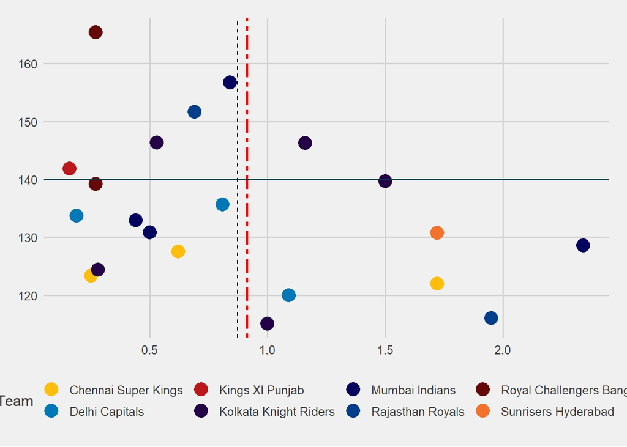

A comparison of Salary against SR in Cluster 3 with SR benchmark at 140.

```r
cluster3 %>% ggplot(aes(Salary, SR, color = Team)) +
  geom_point(size = 5) +
  geom_vline(xintercept = mean(cluster3$Salary), linetype = 2) +
  geom_vline(xintercept = mean(sub_df$Salary), linetype = 6 , size = 1, color = "red") +
  geom_hline(yintercept = 140, linetype = 1, color = "#073b4c") +
  scale_color_manual(values = c("Mumbai Indians" = "#03045e",
                               "Chennai Super Kings" = "#ffbe0b",
                               "Rajasthan Royals" = "#023e8a",
                               "Kolkata Knight Riders" = "#240046",
                               "Delhi Capitals" = "#0077b6",
                               "Sunrisers Hyderabad" = "#f3722c",
                               "Kings XI Punjab" = "#ba181b",
                               "Royal Challengers Bangalore" = "#660708")) +
  theme_fivethirtyeight()
```

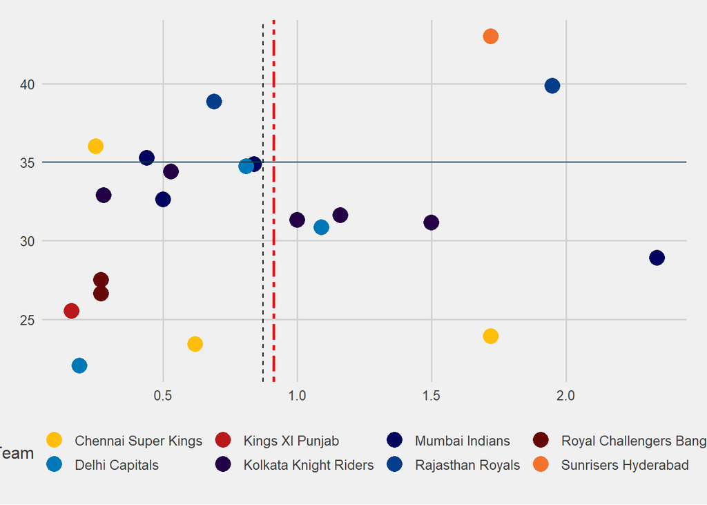

Comparison of Salary against Avg in Cluster 3 with Avg benchmark at 35.

```r
cluster3 %>% ggplot(aes(Salary, Avg, color = Team)) +
  geom_point(size = 5) +
  geom_vline(xintercept = mean(cluster3$Salary), linetype = 2) +
  geom_vline(xintercept = mean(sub_df$Salary), linetype = 6 , size = 1, color = "red") +
  geom_hline(yintercept = 35, linetype = 1, color = "#073b4c") +
  scale_color_manual(values = c("Mumbai Indians" = "#03045e",
                                "Chennai Super Kings" = "#ffbe0b",
                                "Rajasthan Royals" = "#023e8a",
                                "Kolkata Knight Riders" = "#240046",
                                "Delhi Capitals" = "#0077b6",
                                "Sunrisers Hyderabad" = "#f3722c",
                                "Kings XI Punjab" = "#ba181b",
                                "Royal Challengers Bangalore" = "#660708")) +
  theme_fivethirtyeight()
```

The average spend in the cluster is $0.87M, which is comparable to the overall average spend. Very few players in the cluster could meet a SR benchmark of 140 or an Avg of 35.

### Cluster 4 (Classification: Underperforming)

```r
cluster4 <- sub_df %>% filter(cluster == 4)

cluster4 %>% arrange(desc(Runs))
```

```
## # A tibble: 37 × 11
##    Player Team   Runs   Avg    SR Hundr…¹ Fifties Salary runs_…² cluster class…³
##    <chr>  <chr> <dbl> <dbl> <dbl>   <dbl>   <dbl>  <dbl>   <dbl>   <int> <ord>
##  1 Ambat… Chen…   282  23.5  93.1       0       1   0.34    0.82       4 Underp…
##  2 Vijay… Sunr…   244  20.3 126.        0       0   0.5     0.49       4 Underp…
##  3 David… King…   213  26.6 130.        0       1   0.47    0.45       4 Underp…
##  4 Marcu… Roya…   211  52.8 135.        0       0   0.97    0.22       4 Underp…
##  5 Colin… Delh…   184  18.4 119.        0       0   0.91    0.2        4 Underp…
##  6 Kruna… Mumb…   183  16.6 122         0       0   1.38    0.13       4 Underp…
##  7 Sarfa… King…   180  45   126.        0       1   0.04    5.04       4 Underp…
##  8 Nicho… King…   168  28   157         0       0   0.6     0.28       4 Underp…
##  9 Mande… King…   165  41.2 138.        0       0   0.22    0.75       4 Underp…
## 10 Kedar… Chen…   162  18    95.8       0       1   1.22    0.13       4 Underp…
## # … with 27 more rows, and abbreviated variable names ¹Hundreds, ²runs_per_k,
## #   ³classification
```

```r
cluster4 %>% filter(Runs > 150) %>% arrange(desc(runs_per_k))
```

```
## # A tibble: 12 × 11
##    Player Team   Runs   Avg    SR Hundr…¹ Fifties Salary runs_…² cluster class…³
##    <chr>  <chr> <dbl> <dbl> <dbl>   <dbl>   <dbl>  <dbl>   <dbl>   <int> <ord>
##  1 Riyan… Raja…   160  32   127.        0       1   0.03    5.59       4 Underp…
##  2 Sarfa… King…   180  45   126.        0       1   0.04    5.04       4 Underp…
##  3 Ambat… Chen…   282  23.5  93.1       0       1   0.34    0.82       4 Underp…
##  4 Mande… King…   165  41.2 138.        0       0   0.22    0.75       4 Underp…
##  5 Vijay… Sunr…   244  20.3 126.        0       0   0.5     0.49       4 Underp…
##  6 David… King…   213  26.6 130.        0       1   0.47    0.45       4 Underp…
##  7 Kane … Sunr…   156  22.3 120         0       1   0.47    0.33       4 Underp…
##  8 Nicho… King…   168  28   157         0       0   0.6     0.28       4 Underp…
##  9 Marcu… Roya…   211  52.8 135.        0       0   0.97    0.22       4 Underp…
## 10 Colin… Delh…   184  18.4 119.        0       0   0.91    0.2        4 Underp…
## 11 Kedar… Chen…   162  18    95.8       0       1   1.22    0.13       4 Underp…
## 12 Kruna… Mumb…   183  16.6 122         0       0   1.38    0.13       4 Underp…
## # … with abbreviated variable names ¹Hundreds, ²runs_per_k, ³classification
```

```r
cluster4 %>% filter(Runs > 150 & Salary < 0.50) %>% arrange(desc(SR))
```

```
## # A tibble: 6 × 11
##   Player  Team   Runs   Avg    SR Hundr…¹ Fifties Salary runs_…² cluster class…³
##   <chr>   <chr> <dbl> <dbl> <dbl>   <dbl>   <dbl>  <dbl>   <dbl>   <int> <ord>
## 1 Mandee… King…   165  41.2 138.        0       0   0.22    0.75       4 Underp…
## 2 David … King…   213  26.6 130.        0       1   0.47    0.45       4 Underp…
## 3 Riyan … Raja…   160  32   127.        0       1   0.03    5.59       4 Underp…
## 4 Sarfar… King…   180  45   126.        0       1   0.04    5.04       4 Underp…
## 5 Kane W… Sunr…   156  22.3 120         0       1   0.47    0.33       4 Underp…
## 6 Ambati… Chen…   282  23.5  93.1       0       1   0.34    0.82       4 Underp…
## # … with abbreviated variable names ¹Hundreds, ²runs_per_k, ³classification
```

```r
cluster4 %>% filter(Runs < 200 & Salary > 1) %>% arrange(desc(Runs))
```

```
## # A tibble: 11 × 11
##    Player Team   Runs   Avg    SR Hundr…¹ Fifties Salary runs_…² cluster class…³
##    <chr>  <chr> <dbl> <dbl> <dbl>   <dbl>   <dbl>  <dbl>   <dbl>   <int> <ord>
##  1 Kruna… Mumb…   183 16.6  122         0       0   1.38    0.13       4 Underp…
##  2 Kedar… Chen…   162 18     95.8       0       1   1.22    0.13       4 Underp…
##  3 Sunil… Kolk…   143 17.9  166.        0       0   1.95    0.07       4 Underp…
##  4 Ben S… Raja…   123 20.5  124.        0       0   1.95    0.06       4 Underp…
##  5 Ravin… Chen…   106 35.3  120.        0       0   1.09    0.1        4 Underp…
##  6 Sam C… King…    95 23.8  173.        0       1   1.03    0.09       4 Underp…
##  7 Jofra… Raja…    67 33.5  168.        0       0   1.12    0.06       4 Underp…
##  8 Ravic… King…    42  8.4  150         0       0   1.19    0.04       4 Underp…
##  9 Rashi… Sunr…    34  6.8  148.        0       0   1.41    0.02       4 Underp…
## 10 Chris… Delh…    32  5.33  86.5       0       0   1.72    0.02       4 Underp…
## 11 Bhuvn… Sunr…    12  4     63.2       0       0   1.33    0.01       4 Underp…
## # … with abbreviated variable names ¹Hundreds, ²runs_per_k, ³classification
```

Cluster 4 contains players under-performing on all or most of parameters for Runs, SR and Avg. Filtering for players with a cost under 0.5M Dollars reveals possible value acquisitions with the category. The cluster also contains 11 players with a cost over $1M and very poor returns in terms of runs. (The analyst is aware that these players might have been acquired for skills other batting. The current analysis restricts itself to batting performances only.)

```r
cluster4 %>% summarise(mean(Salary))
```

```
## # A tibble: 1 × 1
##   `mean(Salary)`
##            <dbl>
## 1          0.736
```

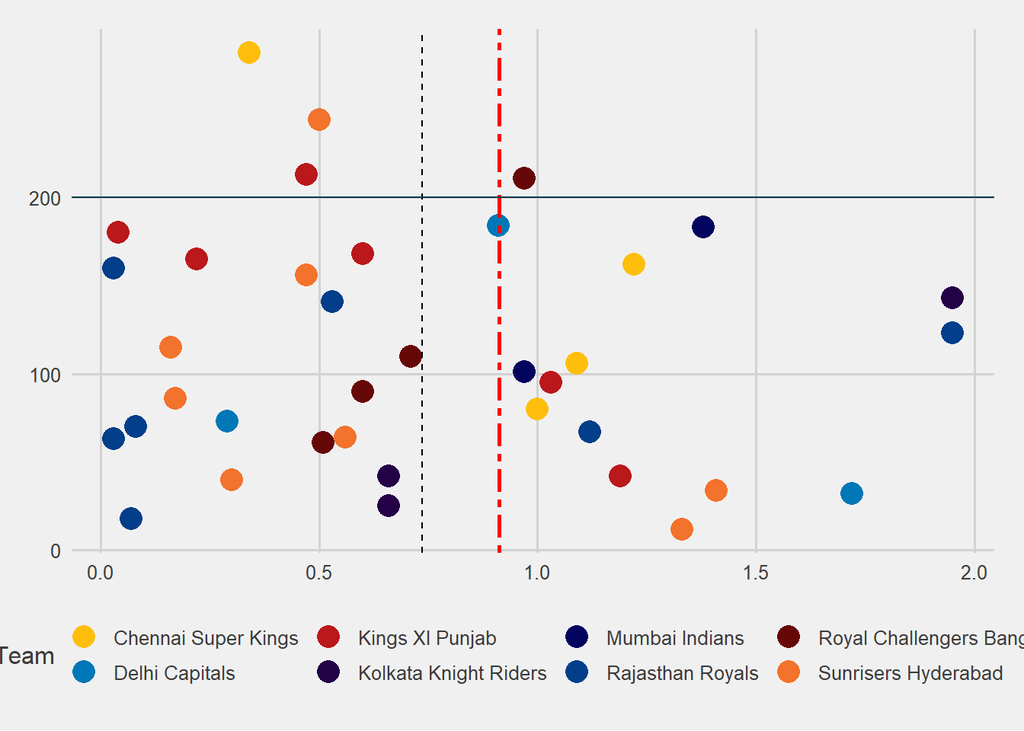

```r
cluster4 %>% ggplot(aes(Salary, Runs, color = Team)) +
  geom_point(size = 5) +
  geom_vline(xintercept = mean(cluster4$Salary), linetype = 2) +
  geom_vline(xintercept = mean(df$Salary), linetype = 6 , size = 1, color = "red") +
  geom_hline(yintercept = 200, linetype = 1, color = "#073b4c") +
  scale_color_manual(values = c("Mumbai Indians" = "#03045e",
                                "Chennai Super Kings" = "#ffbe0b",
                                "Rajasthan Royals" = "#023e8a",
                                "Kolkata Knight Riders" = "#240046",
                                "Delhi Capitals" = "#0077b6",
                                "Sunrisers Hyderabad" = "#f3722c",
                                "Kings XI Punjab" = "#ba181b",
                                "Royal Challengers Bangalore" = "#660708")) +
  theme_fivethirtyeight()
```

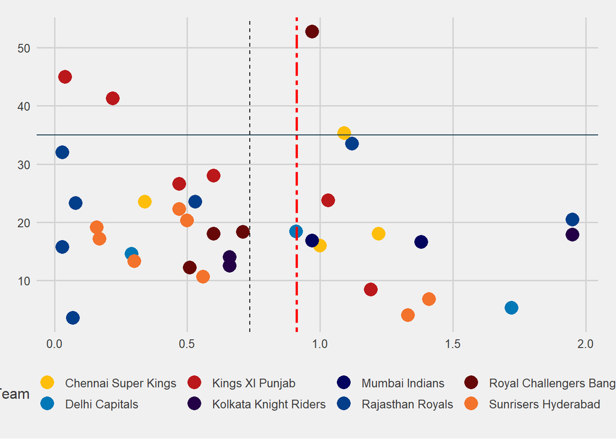

Comparison of Salary against Avg in Cluster 4 with Avg benchmark at 35.

```r
cluster4 %>% ggplot(aes(Salary, Avg, color = Team)) +
  geom_point(size = 5) +
  geom_vline(xintercept = mean(cluster4$Salary), linetype = 2) +
  geom_vline(xintercept = mean(df$Salary), linetype = 6 , size = 1, color = "red") +
  geom_hline(yintercept = 35, linetype = 1, color = "#073b4c") +
  scale_color_manual(values = c("Mumbai Indians" = "#03045e",
                                "Chennai Super Kings" = "#ffbe0b",
                                "Rajasthan Royals" = "#023e8a",
                                "Kolkata Knight Riders" = "#240046",
                                "Delhi Capitals" = "#0077b6",
                                "Sunrisers Hyderabad" = "#f3722c",
                                "Kings XI Punjab" = "#ba181b",
                                "Royal Challengers Bangalore" = "#660708")) +
  theme_fivethirtyeight()
```

The average money spent on players in cluster 4 is $0.73M and is well below the overall average. Very few players could achieve benchmarks for Runs @ 200 and Avg @ 35.

# Overall Analysis

The analysis will now focus on the composition of the Teams and the proportions of the 4 Classifications within the Teams

```r
df_tab <- table(sub_df$Team, sub_df$classification)
df_tab
```

```
##
##                               Excellent Good Average Underperforming
##   Chennai Super Kings                 0    1       3               4
##   Delhi Capitals                      0    1       3               3
##   Kings XI Punjab                     1    1       1               6
##   Kolkata Knight Riders               0    1       5               3
##   Mumbai Indians                      0    1       4               2
##   Rajasthan Royals                    2    0       2               7
##   Royal Challengers Bangalore         1    1       2               4
##   Sunrisers Hyderabad                 2    0       1               8
```

```r
sub_df %>% group_by(Team) %>% summarise(Total_Salary = sum(Salary)) %>% arrange(desc(Total_Salary))
```

```
## # A tibble: 8 × 2
##   Team                        Total_Salary
##   <chr>                              <dbl>
## 1 Kolkata Knight Riders               9.07
## 2 Sunrisers Hyderabad                 8.88
## 3 Chennai Super Kings                 8.58
## 4 Rajasthan Royals                    8.32
## 5 Mumbai Indians                      8.19
## 6 Royal Challengers Bangalore         7.71
## 7 Delhi Capitals                      7.35
## 8 Kings XI Punjab                     5.74
```

```r
prop_team <- round(prop.table(df_tab, 1), digits = 2)
prop_team
```

```
##
##                               Excellent Good Average Underperforming
##   Chennai Super Kings              0.00 0.12    0.38            0.50
##   Delhi Capitals                   0.00 0.14    0.43            0.43
##   Kings XI Punjab                  0.11 0.11    0.11            0.67
##   Kolkata Knight Riders            0.00 0.11    0.56            0.33
##   Mumbai Indians                   0.00 0.14    0.57            0.29
##   Rajasthan Royals                 0.18 0.00    0.18            0.64
##   Royal Challengers Bangalore      0.12 0.12    0.25            0.50
##   Sunrisers Hyderabad              0.18 0.00    0.09            0.73
```

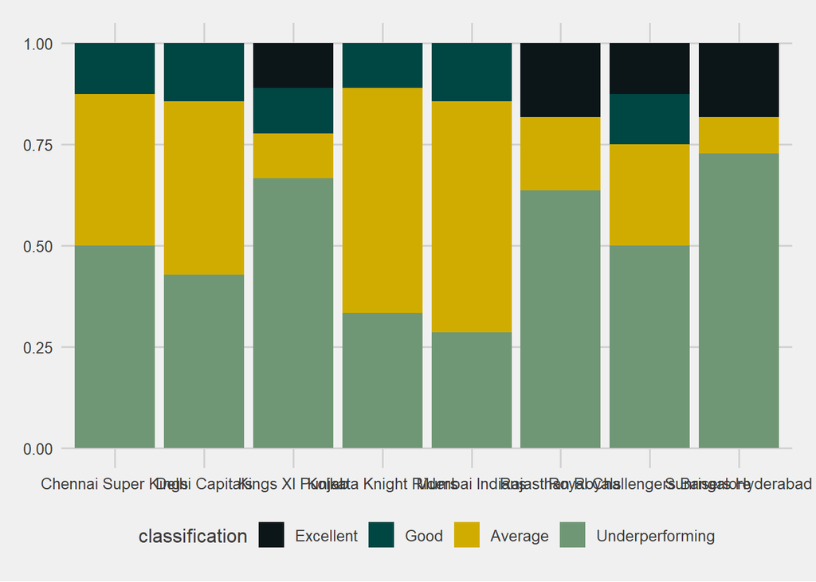

```r
ggplot(sub_df, aes(Team, fill = classification)) +
  geom_bar(position = "fill") +
  scale_fill_manual(values = c("#0c1618", "#004643", "#d1ac00", "#709775")) +
  theme_fivethirtyeight()
```

A view of proportions reveals an unfavorable composition for Sunrisers Hyderabad, who have the second highest payroll at $8.88M and 73% of their players appear to be underperforming. The team of Mumbai Indians appear to have the most favorable ratio of Average to Underperforming players. This may be considered a positive given that they have the 5th highest payroll.

```r
prop_class <- round(prop.table(df_tab, 2), digits = 2)
prop_class
```

```
##
##                               Excellent Good Average Underperforming
##   Chennai Super Kings              0.00 0.17    0.14            0.11
##   Delhi Capitals                   0.00 0.17    0.14            0.08
##   Kings XI Punjab                  0.17 0.17    0.05            0.16
##   Kolkata Knight Riders            0.00 0.17    0.24            0.08
##   Mumbai Indians                   0.00 0.17    0.19            0.05
##   Rajasthan Royals                 0.33 0.00    0.10            0.19
##   Royal Challengers Bangalore      0.17 0.17    0.10            0.11
##   Sunrisers Hyderabad              0.33 0.00    0.05            0.22
```

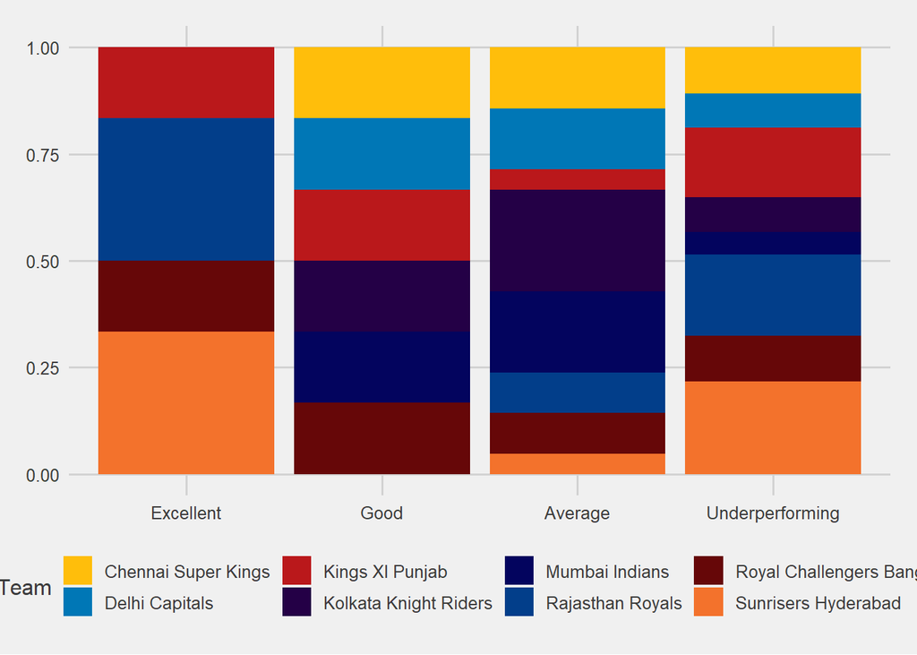

```r
ggplot(sub_df, aes(classification, fill = Team)) +
  geom_bar(position = "fill") +
  scale_fill_manual(values = c("Mumbai Indians" = "#03045e",
                                "Chennai Super Kings" = "#ffbe0b",
                                "Rajasthan Royals" = "#023e8a",
                                "Kolkata Knight Riders" = "#240046",
                                "Delhi Capitals" = "#0077b6",
                                "Sunrisers Hyderabad" = "#f3722c",
                                "Kings XI Punjab" = "#ba181b",
                                "Royal Challengers Bangalore" = "#660708")) +
  theme_fivethirtyeight()
```

An alternate proportional view of Classifications shows Sunrisers Hyderabad featuring in the 2 extreme categories. Comparing this against a high payroll could reveal them overspending on high value players leaving a budget shortfall to spend on Good and Average players. A positive assessment can be made for Mumbai Indians, Kolkata Knight Riders and Delhi Capitals. All 3 teams have a fair share of Good and Average players and a lower proportion of Underperformers. The Delhi Capitals with the second lowest payroll, can be said to have a favorable balance of price and performance.

# Conclusion

```r
sub_df %>% group_by(classification) %>% summarise(Avg_Salary = round(mean(Salary), digits = 2),
                                                  Total_Runs = sum(Runs),
                                                  Avg_of_Avgs = mean(Avg),
                                                  Avg_Sr = mean(SR))
```

```
## # A tibble: 4 × 5
##   classification  Avg_Salary Total_Runs Avg_of_Avgs Avg_Sr
##   <ord>                <dbl>      <dbl>       <dbl>  <dbl>
## 1 Excellent             1.42       2929        46.5   144.
## 2 Good                  1.63       2748        51.2   167.
## 3 Average               0.87       7630        31.7   135.
## 4 Underperforming       0.74       4141        20.2   125.
```

The analysis was able to identify 2 groups of high performing player along with par and under-performers. With the average spend for the top 2 classes being double the other 2, Teams would be advised to identify bargain pick ups like Jonny Bairstow (Sunrisers Hyderabad) and Chris Gayle (Kings XI). Cluster 3 (Average) reveals multiple marquee players (Rohit Sharma, Steve Smith, Suresh Raina) that have been picked up at premium prices but have delivered underwhelming results. As per the present analysis, it would be prudent for teams to limits premium player to one or two and leave enough payroll space to increase their share in the average group.

# Adding the classifications to the original dataset

```r
ipl_batsmen_data$Classification <- sub_df$classification
ipl_batsmen_data
```

```
## # A tibble: 70 × 13
##     ...1 ...2  Player Team   Runs   Avg    SR Hundr…¹ Fifties Fours Sixes Salary
##    <dbl> <lgl> <chr>  <chr> <dbl> <dbl> <dbl>   <dbl>   <dbl> <dbl> <dbl>  <dbl>
##  1     1 NA    AB de… Roya…   442  44.2 154         0       5    31    26  1.72
##  2     2 NA    Ajink… Raja…   393  32.8 138.        1       1    45     9  0.625
##  3     3 NA    Akshd… Roya…    61  12.2 107.        0       0     5     2  0.514
##  4     4 NA    Ambat… Chen…   282  23.5  93.1       0       1    20     7  0.344
##  5     5 NA    Andre… Kolk…   510  56.7 205.        0       4    31    52  1.33
##  6     6 NA    Axar … Roya…   110  18.3 125         0       0    10     3  0.714
##  7     7 NA    Ben S… Raja…   123  20.5 124.        0       0     8     4  1.95
##  8     8 NA    Bhuvn… Sunr…    12   4    63.2       0       0     1     0  1.33
##  9     9 NA    Chris… King…   490  40.8 154.        0       4    45    34  0.312
## 10    10 NA    Chris… Kolk…   405  31.2 140.        0       4    41    22  1.5
## # … with 60 more rows, 1 more variable: Classification <ord>, and abbreviated
## #   variable name ¹Hundreds
```